[output not shown]

## Introduction

- What is an Internet of Things (IoT) system?
- Examples
- Smart Homes
- Predictive Maintenance
- Healthcare
- Traffic systems
- Growing Relevance

## Protecting our Systems

- Lots of sensors collecting data
- Data can be a target
- Systems may also be targeted to disrupt them
- This leads to the question I will answer:
  - Can we use real- time metrics to determine if network access is malicious or not?

## Importing data

- import data with the read.csv function

```r
cyber_data <- read.csv("C:/Users/ethan/OneDrive - Georgia College/R/Statistical Computing Final/RT_IOT2022.csv")
dim(cyber_data)
```

```
## [1] 123117     85
```

## looking for Missing Values

- NA values?

```r
sum(is.na(cyber_data))
```

```
## [1] 0
```

- No NA values. Lucky!
- Removing ‘service’ feature and another column with all 0s

```r
cyber_data = cyber_data |>
  select(- service) |>
  select(- bwd_URG_flag_count)
```

## More model Trimming

- We know we should drop ID columns to prevent overfitting models, as ID provides no actual information

```r
cyber_data = cyber_data |>
  select(- id.orig_p) |>
  select(- id.resp_p) |>
  select(- X)
dim(cyber_data)
```

```
## [1] 123117     80
```

```r
head(cyber_data)
```

```
##   proto flow_duration fwd_pkts_tot bwd_pkts_tot fwd_data_pkts_tot
## 1   tcp      32.01160            9            5                 3
## 2   tcp      31.88358            9            5                 3
## 3   tcp      32.12405            9            5                 3
## 4   tcp      31.96106            9            5                 3
## 5   tcp      31.90236            9            5                 3
## 6   tcp      31.86969            9            5                 3
##   bwd_data_pkts_tot fwd_pkts_per_sec bwd_pkts_per_sec flow_pkts_per_sec
## 1                 3         0.281148         0.156193          0.437341
## 2                 3         0.282277         0.156821          0.439097
## 3                 3         0.280164         0.155647          0.435811
## 4                 3         0.281593         0.156440          0.438033
## 5                 3         0.282111         0.156728          0.438839
## 6                 3         0.282400         0.156889          0.439289
##   down_up_ratio fwd_header_size_tot fwd_header_size_min fwd_header_size_max
```

[output cut: 125 more lines]

## Wrangling

- create new feature that specifies if network access is hostile or not
- For Attack_types column:
  - MQTT, Thing_Speak, Wipro_bulb_dataset are all normal
  - Other types are hostile

```r
cyber_data = cyber_data |>
  mutate(Attack = case_when(
    Attack_type == 'MQTT_Publish' ~ FALSE,
    Attack_type == 'Thing_Speak' ~ FALSE,
    Attack_type == 'Wipro_bulb' ~ FALSE,
    .default = TRUE ))

cyber_data |> count(Attack)
```

```
##   Attack      n
## 1  FALSE  12507
## 2   TRUE 110610
```

```r
cyber_data <-  cyber_data |>
  mutate(Attack_type = factor(Attack_type))
```

## Wrangling

- Standardize remaining data

```r
cyber_data_scaled <-  cyber_data |>
  select(where(is.numeric)) |>
  scale()
unscaled_cols <-  cyber_data |> select(- where(is.numeric))
cyber_data_scaled = cbind(cyber_data_scaled, unscaled_cols)

dim(cyber_data_scaled) == dim(cyber_data)
```

```
## [1] TRUE TRUE
```

## Exploratory Data Analysis

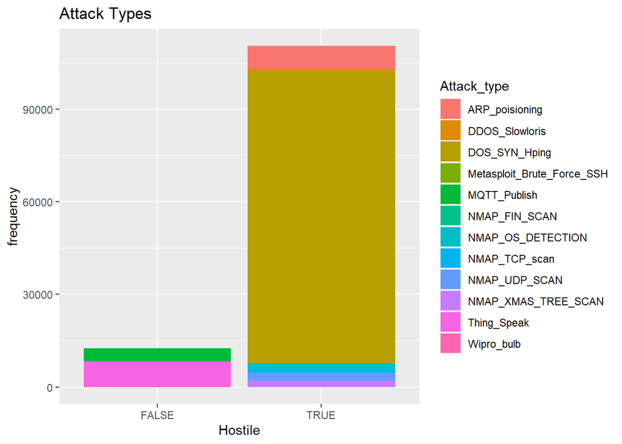

## EDA

- Visualize total attacks based on proportion

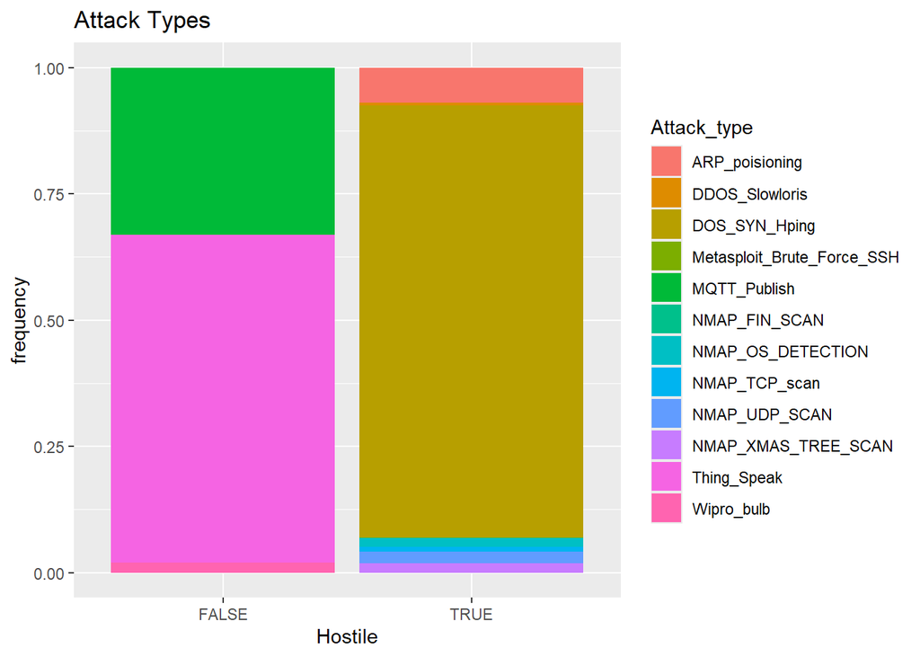

## Model Building - Principal Componenet Analysis

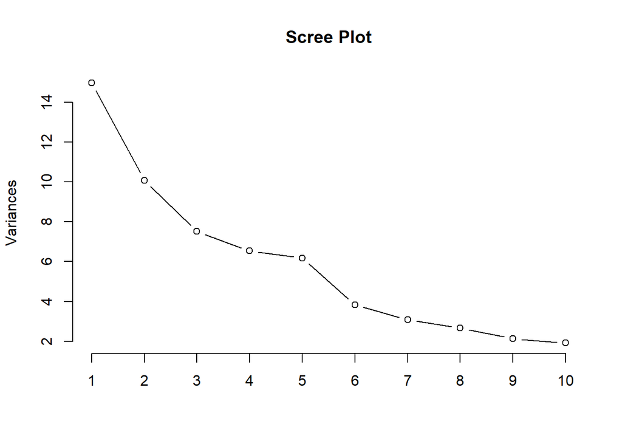

## PCA

```r
summary(pca_cyber)$importance[,1:10]
```

```
##                            PC1      PC2      PC3      PC4      PC5      PC6
## Standard deviation     3.86769 3.173754 2.741045 2.556794 2.486216 1.955906
## Proportion of Variance 0.19178 0.129140 0.096320 0.083810 0.079250 0.049050
## Cumulative Proportion  0.19178 0.320920 0.417240 0.501050 0.580300 0.629350
##                             PC7      PC8      PC9     PC10
## Standard deviation     1.756335 1.630435 1.459396 1.385812
## Proportion of Variance 0.039550 0.034080 0.027310 0.024620
## Cumulative Proportion  0.668900 0.702980 0.730280 0.754900
```

- based on the elbow method and the cumulative proportion, 6 seems like a good choice

```
##         PC1      PC2      PC3      PC4         PC5       PC6 Attack
## 1 -8.191645 6.222624 3.066887 3.143480 0.005352682 -3.420257  FALSE
## 2 -8.169889 6.221026 3.069208 3.168894 0.006922390 -3.301154  FALSE
## 3 -8.201057 6.239719 3.088417 3.155604 0.006863079 -3.424348  FALSE
## 4 -8.175296 6.232446 3.086104 3.175628 0.008083857 -3.313669  FALSE
## 5 -8.179590 6.223897 3.069452 3.161953 0.006504783 -3.317376  FALSE
## 6 -8.165596 6.216442 3.066034 3.165691 0.006607388 -3.313523  FALSE
##    Attack_type
## 1 MQTT_Publish
## 2 MQTT_Publish
## 3 MQTT_Publish
## 4 MQTT_Publish
## 5 MQTT_Publish
## 6 MQTT_Publish
```

```r
dim(pca_scores)
```

```
## [1] 123117      8
```

## Model Building T- T split

- As discussed earlier, need stratification when creating our split due to data imbalance

```r
cyber_train <-  pca_scores |>
  group_by(Attack_type) |>
  sample_frac(0.7)
cyber_test <-  anti_join(pca_scores, cyber_train)
```

## Building our model

- Our objective is classification, so we will try two models:
- K- Nearest- Neighbors
- Random Forest
- Why these models?
- Logreg not great for imbalanced data from my understanding

## K- NN Setting up Workflow

- Using workflow from tidymodels allows us to pipline the hyperparamater tuning and then seamlessly choose the best one

```r
#allows us to use multiple cpu cores
plan(multisession, workers = 4)

#model -  where we set our model type and hyperparamater tuning
knn_model <-  nearest_neighbor(
  neighbors=tune(), #this is the h- p we want to tune
  weight_func = 'rectangular',
  dist_power = 2) |>
  set_engine('kknn') |>
  set_mode('classification')

#recipe is basically our formula
knn_recipe <-  cyber_train |>
  select(- Attack) |>
  recipe(Attack_type~.)
```

## K- NN Using CV to tune HP

```r
#workflow object -  combine recipe and model
knn_wf <-  workflow() |>
  add_model(knn_model) |>
  add_recipe(knn_recipe)

#cross- validation splits
folds <-  vfold_cv(cyber_train, v=5, strata = Attack_type)

#object that specifies the intervals and range
knn_grid <-  grid_regular(neighbors(range=c(1,20)), levels =10)

#here is where we actually train.
tune_results <-  tune_grid(
  knn_wf,
  resamples = folds,
  grid = knn_grid,
  metrics = metric_set(precision, recall, f_meas) #macro
)
```

[output not shown]

[output not shown]

[output not shown]

[output not shown]

[output not shown]

## K- NN Results

```r
#display our result
tune_results |>
  collect_metrics()
```

```
## # A tibble: 30 × 7
##    neighbors .metric   .estimator  mean     n std_err .config
##        <int> <chr>     <chr>      <dbl> <int>   <dbl> <chr>
##  1         1 f_meas    macro      0.923     5 0.00479 Preprocessor1_Model01
##  2         1 precision macro      0.933     5 0.0109  Preprocessor1_Model01
##  3         1 recall    macro      0.924     5 0.00659 Preprocessor1_Model01
##  4         3 f_meas    macro      0.927     5 0.00871 Preprocessor1_Model02
##  5         3 precision macro      0.944     5 0.0122  Preprocessor1_Model02
##  6         3 recall    macro      0.923     5 0.00553 Preprocessor1_Model02
##  7         5 f_meas    macro      0.928     5 0.00652 Preprocessor1_Model03
##  8         5 precision macro      0.947     5 0.00873 Preprocessor1_Model03
##  9         5 recall    macro      0.919     5 0.00492 Preprocessor1_Model03
## 10         7 f_meas    macro      0.922     5 0.00543 Preprocessor1_Model04
## # ℹ 20 more rows
```

```r
#save the best k value
best_k <-  tune_results |>
  select_best(metric = 'f_meas')
```

## K- NN Graphs

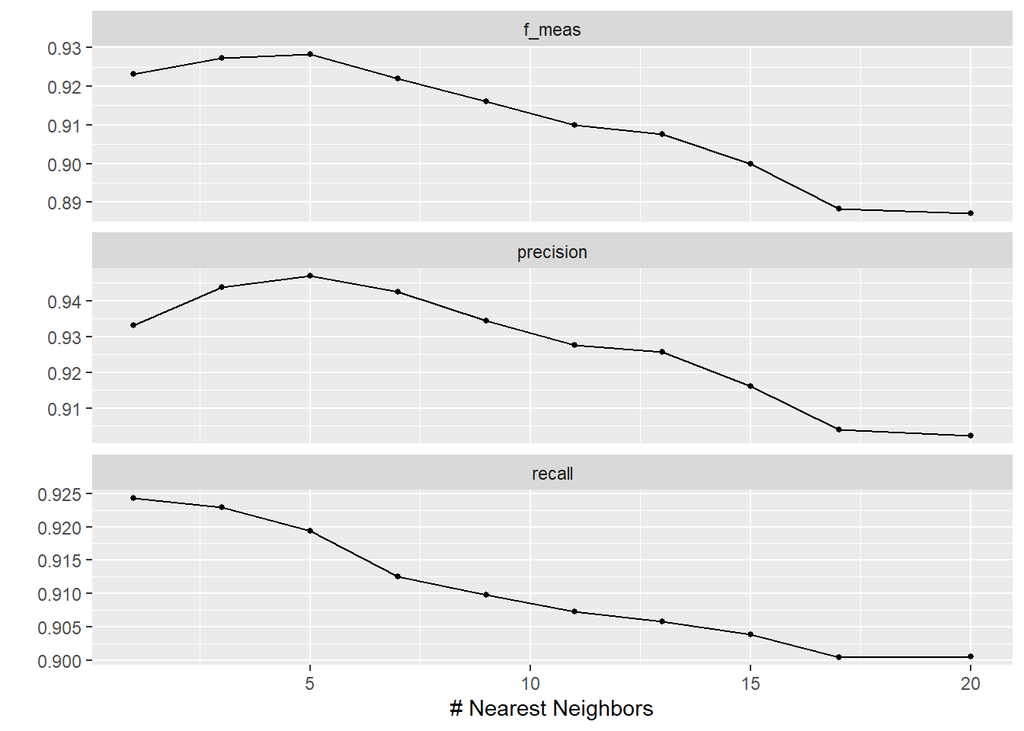

## K- NN Testing

```
## # A tibble: 3 × 3
##   .metric   .estimator knn_estimate
##   <chr>     <chr>             <dbl>
## 1 precision macro             0.888
## 2 recall    macro             0.805
## 3 f_meas    macro             0.881
```

## Random Forest - Setting up Model

- Exact same process for Random Forest, but we will tune mtry and #of trees
- Used ranger package

```r
rf_model <-  rand_forest(
  mode='classification',
  mtry = tune(),
  trees = tune())|>
  set_engine('ranger')

rf_grid <-  grid_regular(
  mtry(range = c(1,2)),
  trees(range = c(100,1000)),
  levels=5
)
```

```
## # A tibble: 5 × 8
##    mtry trees .metric .estimator  mean     n std_err .config
##   <int> <int> <chr>   <chr>      <dbl> <int>   <dbl> <chr>
## 1     2   775 f_meas  macro      0.957     5 0.00258 Preprocessor1_Model08
## 2     2  1000 f_meas  macro      0.957     5 0.00232 Preprocessor1_Model10
## 3     1  1000 f_meas  macro      0.957     5 0.00239 Preprocessor1_Model09
## 4     1   100 f_meas  macro      0.957     5 0.00191 Preprocessor1_Model01
## 5     2   325 f_meas  macro      0.957     5 0.00240 Preprocessor1_Model04
```

```
## # A tibble: 1 × 3
##    mtry trees .config
##   <int> <int> <chr>
## 1     2   775 Preprocessor1_Model08
```

## RF - Finalizing Workflow and Results

```
## # A tibble: 3 × 3
##   .metric   .estimator rf_estimate
##   <chr>     <chr>            <dbl>
## 1 precision macro            0.940
## 2 recall    macro            0.815
## 3 f_meas    macro            0.911
```

## RF 100 Tree Model

- Since scores were comparable, I wanted to look at a final verson of the 100 tree model.

```
## # A tibble: 3 × 2
##   .metric   rf_100_estimate
##   <chr>               <dbl>
## 1 precision           0.941
## 2 recall              0.814
## 3 f_meas              0.911
```

## Conclusion

- Both models preform considerably well despite class imbalance
- given the large nature of this dataset, k- nn could take up too much system memory to be realistic to implement in a IoT network.
- The answer to our question appears to be yes

```r
rf_100_metrics |>
  bind_cols(rf_metrics |> select(rf_estimate))|>
  bind_cols(knn_metrics |> select(knn_estimate)) |>
  select(-.estimator)
```

```
## # A tibble: 3 × 4
##   .metric   rf_100_estimate rf_estimate knn_estimate
##   <chr>               <dbl>       <dbl>        <dbl>
## 1 precision           0.941       0.940        0.888
## 2 recall              0.814       0.815        0.805
## 3 f_meas              0.911       0.911        0.881
```

## Sources

- Data: S., B. and Rohini Nagapadma. “RT- IoT2022 .” UCI Machine Learning Repository, 2023, https://doi.org/10.24432/C5P338.
- great resource
- https://dials.tidymodels.org/reference/index.html
- tidymodels website is pretty good
- Class Notes